# Swiss electricty exports forecasts

Group 1: Samy Maurer, Alexander Liden, Tiffany Davies, Manon Verjus

23/05/2023

First of all let us import the data :

```r
#import data
library(readxl)
library(feasts)
library(ggseas)
library(tsibble)
library(feasts)
library(forecast)
```

```r
library(fabletools)
library(ggplot2)
library(fable)
library(patchwork)

Electricityraw <- read_excel("Electricity export Switzerland-3.xlsx")
```

# Data cleaning and Wrangling

We started our project by importing the data set and doing some basic modification of the raw data in order to be a bit more readable data set.

```r
# Rename the columns
colnames(Electricityraw) <- c("Date", "Germany", "France", "Austria", "Liechtenstein", "Italy", "Total.Export")
# Remove the first 4 rows
Electricity <- Electricityraw[-c(1:4), ]
# Change Oktober for October
Electricity$Date <- gsub("Oktober", "October", Electricity$Date)
# Convert the date column to a date object
Electricity$Date <- as.Date(paste0("01 ", Electricity$Date), format = "%d %B %Y")
```

The columns were in a character form, so we trandormed them in a numeric format since they represent continuous values.

```r
# Convert the electricity export columns to numeric
Electricity$Germany <- as.numeric(Electricity$Germany)
Electricity$France <- as.numeric(Electricity$France)
Electricity$Austria <- as.numeric(Electricity$Austria)
Electricity$Liechtenstein <- as.numeric(Electricity$Liechtenstein)
Electricity$Italy <- as.numeric(Electricity$Italy)
Electricity$Total.Export <- as.numeric(Electricity$Total.Export)
```

In order to control that our data set is full, we print NA values. As we have 0 NA values for all the columns, we should not have any missing values.

```r
# Check if there are any missing values in the dataset
missing_values <- is.na(Electricity)

# Check if any columns contain missing values
missing_values_per_column <- colSums(missing_values)
print(missing_values_per_column)
```

```
##          Date       Germany        France       Austria Liechtenstein
##             0             0             0             0             0
##         Italy  Total.Export
##             0             0
```

# Vizualisation

## Time series

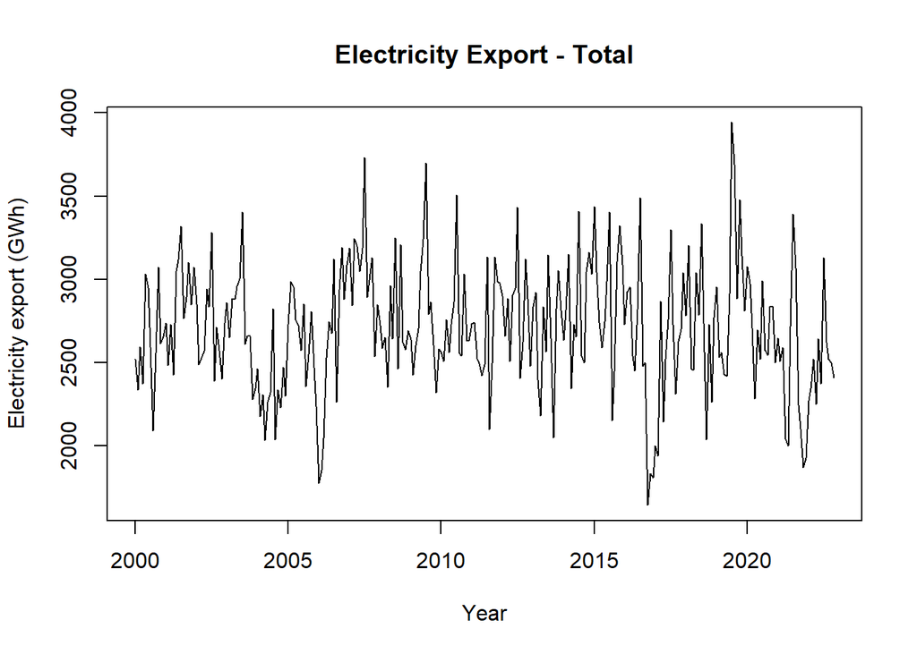

```r
# Create a time series object for the Total.Export data
ts_data <- ts(Electricity$Total.Export, start = c(2000, 1), frequency = 12)
# Create a time series object for the Germany data
ts_germany <- ts(Electricity$Germany, start = c(2000, 1), frequency = 12)
# Create a time series object for the France data
ts_france <- ts(Electricity$France, start = c(2000, 1), frequency = 12)
# Create a time series object for the Italy data
ts_italy <- ts(Electricity$Italy, start = c(2000, 1), frequency = 12)
# Create a time series object for the Austria data
ts_austria <- ts(Electricity$Austria, start = c(2000, 1), frequency = 12)
# Create a time series object for the Liechtenstein data
ts_liechtenstein <- ts(Electricity$Liechtenstein, start = c(2000, 1), frequency = 12)
# Plot the Total.Export time series
plot(ts_data, xlab = "Year", ylab = "Electricity export (GWh)", main = "Electricity Export - Total")
```

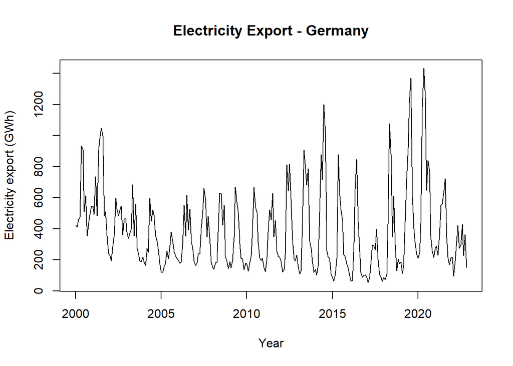

```r
# Plot the Germany time series
plot(ts_germany, xlab = "Year", ylab = "Electricity export (GWh)", main = "Electricity Export - Germany")
```

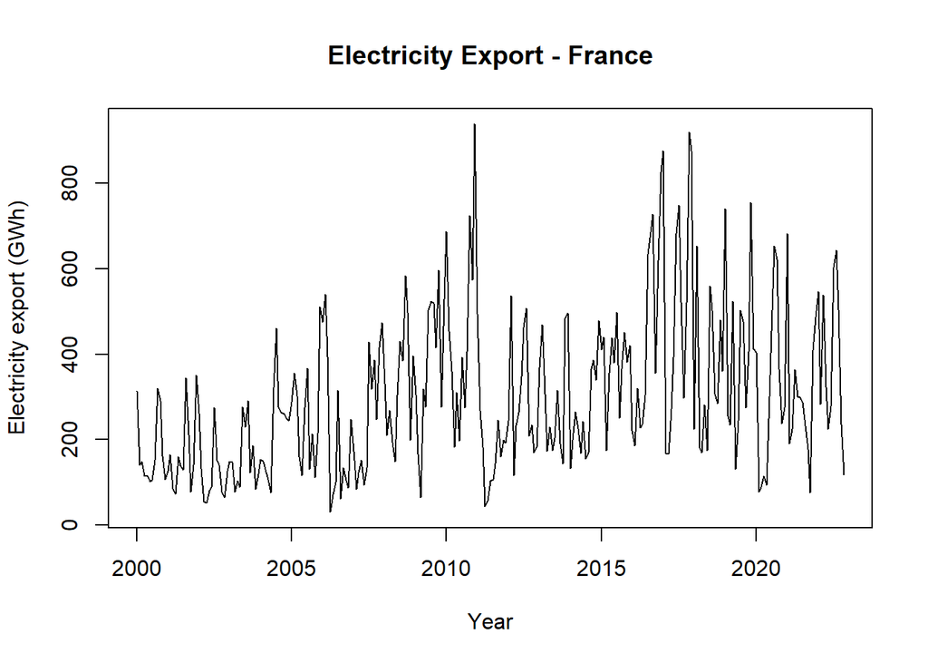

```r
# Plot the France time series
plot(ts_france, xlab = "Year", ylab = "Electricity export (GWh)", main = "Electricity Export - France")
```

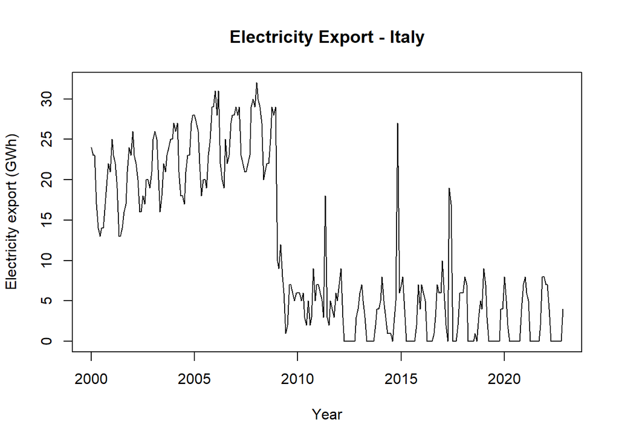

```r
# Plot the Italy time series
plot(ts_italy, xlab = "Year", ylab = "Electricity export (GWh)", main = "Electricity Export - Italy")
```

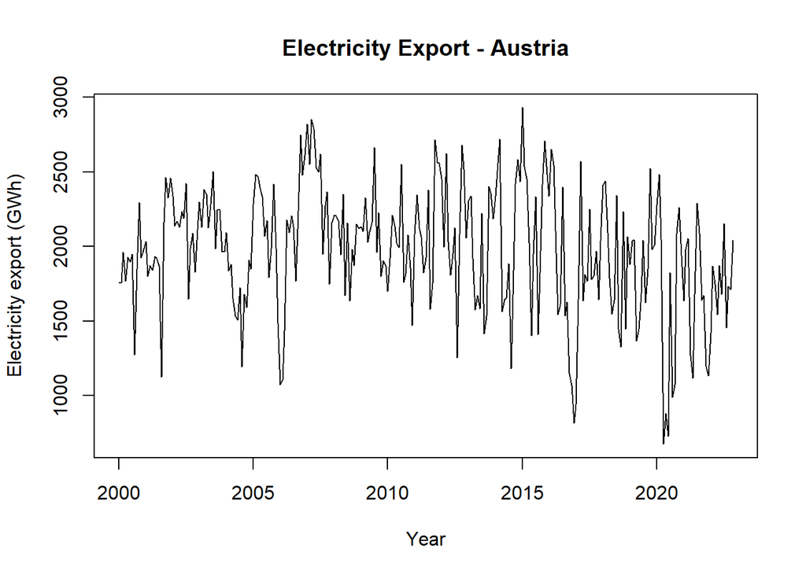

```r
# Plot the Austria time series
plot(ts_austria, xlab = "Year", ylab = "Electricity export (GWh)", main = "Electricity Export - Austria")
```

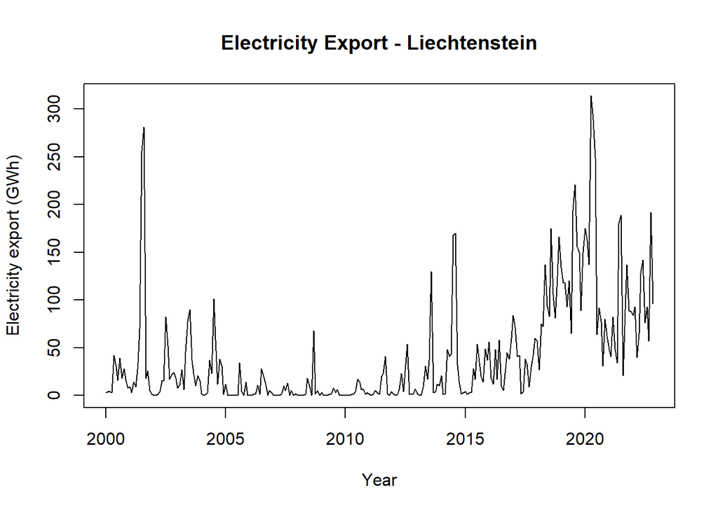

```r
# Plot the Liechtenstein time series
plot(ts_liechtenstein, xlab = "Year", ylab = "Electricity export (GWh)", main = "Electricity Export - Liechtenstein")
```

## STL Decomposition

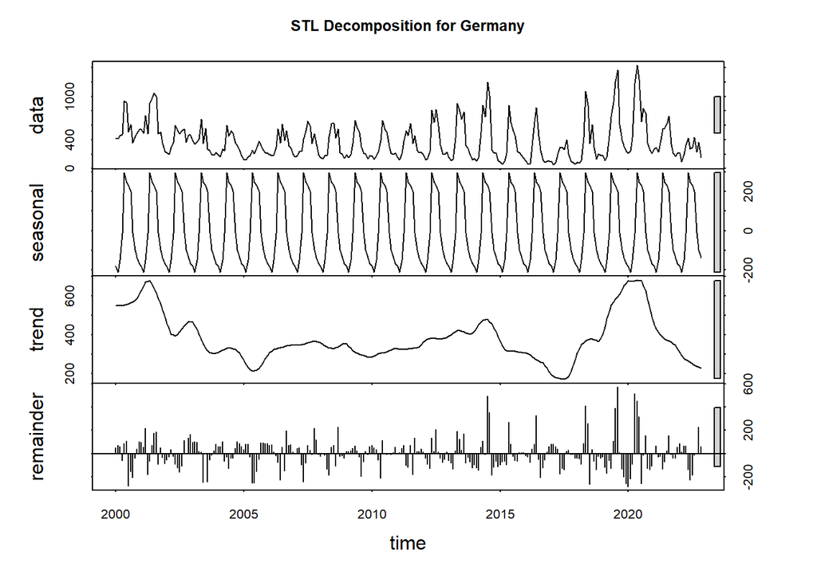

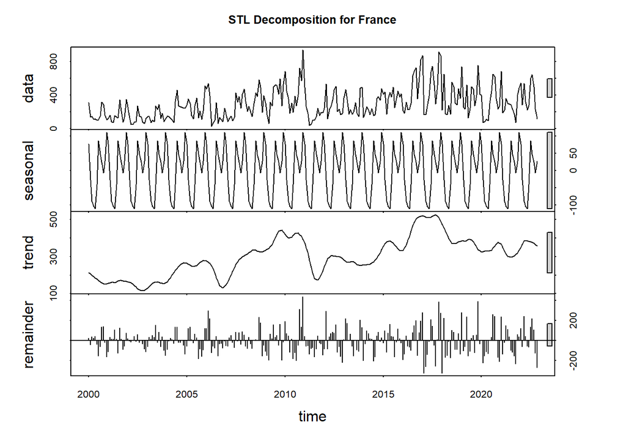

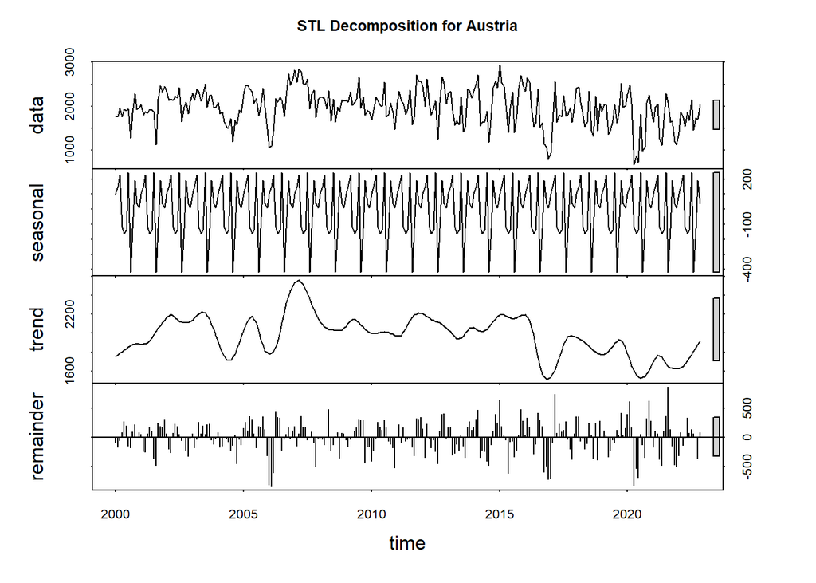

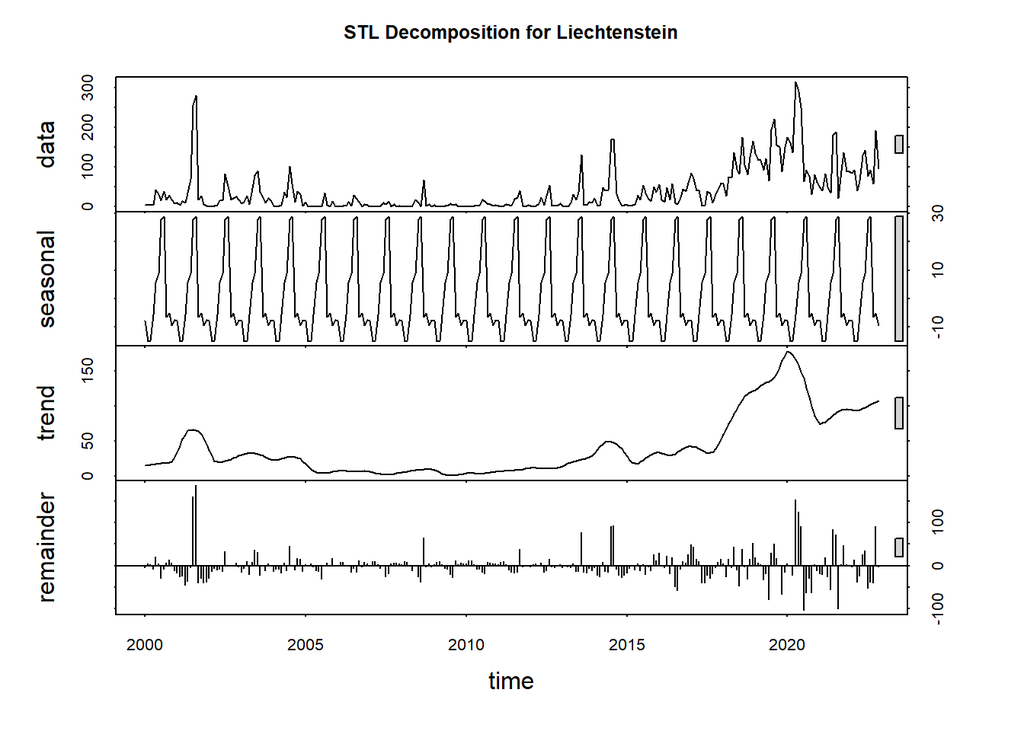

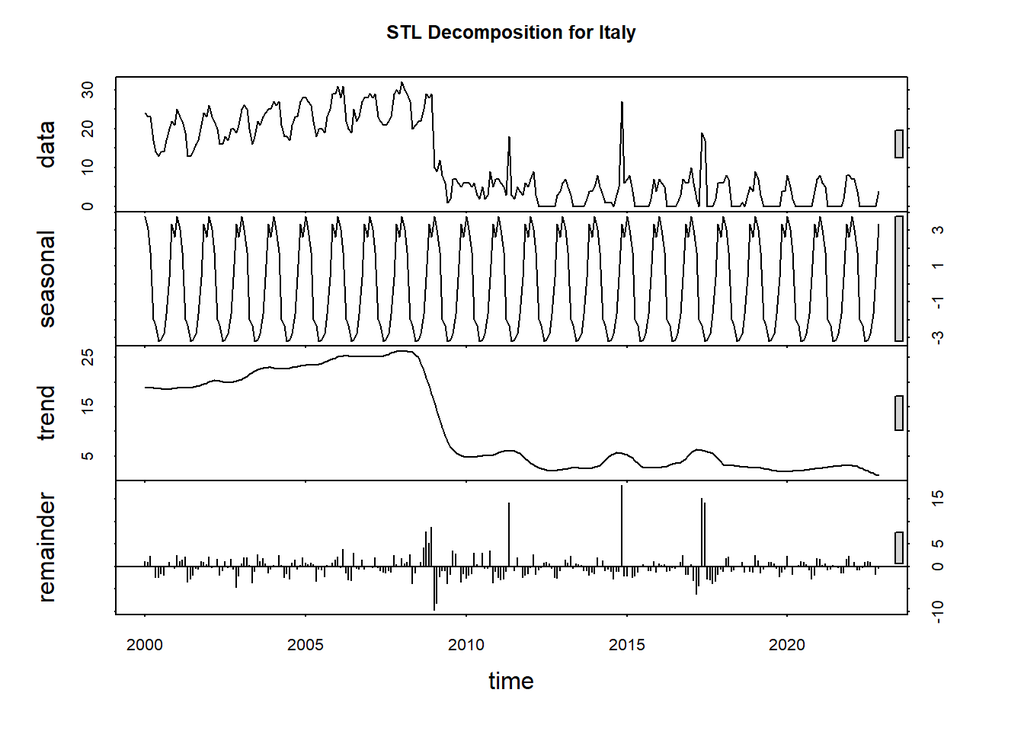

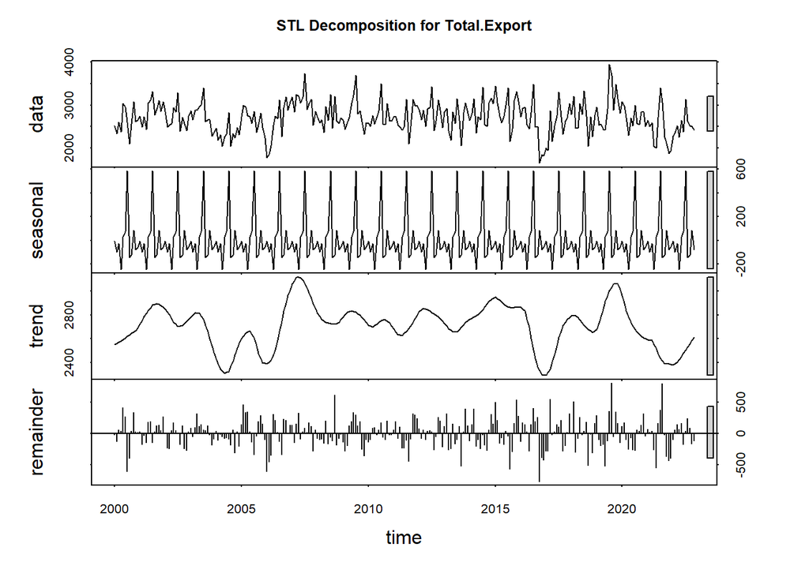

```r
# Define the countries vector
countries <- c("Germany", "France", "Austria", "Liechtenstein", "Italy", "Total.Export")

# Function to create and plot seasonal decomposition for a given country
plot_stl_decomposition <- function(data, country) {
  # Create a time series object
  country_ts <- ts(data[[country]], start = c(2000, 1), frequency = 12)

  # Perform STL decomposition
  country_stl <- stl(country_ts, s.window = "periodic")

  # Plot the seasonal decomposition
  plot(country_stl, main = paste("STL Decomposition for", country))
}

# Use the function to create and display STL decomposition plots for each country
for (country in countries) {
  plot_stl_decomposition(Electricity, country)
}
```

Based on the time series results, we plotted a STL decomposition to see if there is some seasonality or not. For Italy, we observe a clear seasonality with raises in Winter and drops in Summer. As for the trend, from 2000 to 2008, we observe a small increase followed by huge drop until 2010. Since 2010, the trend is constant. For Lichtenstein, we identify seasonality with drops every beginning of the years while raising for the Summer. The trend shows constant value until 2017 where there is a huge raise until 2020. This raise is followed by a drop until 2021 and then a small increase. We find out remainders for some countries. It is especially the case for Germany, France and Austria. The remainders could be random noises or it could be explained by irregular effects, model misspecification that does not capture the patterns or nonlinear relationship.

To better observe seasonality, we did seasonal subseries plots. You can find the visualisation plots in the appendix. On the following graph, we examine the seasonaly of the volume of exports per country. It is interesting to see that some months have more exports than others. Basically, we see that summer is a month with a lot of exports, especially July. This is not true for Italy with some years without exportation at all. At the same time, we notice that the scale is not the same for all the countries. This increase of exports during summer could be explained by several factors as seasonal demands from countries but also tourism and weather.

```r
# Convert the time series objects to tsibble objects
ts_data_tsibble <- ts_data %>% as_tsibble(index = index(ts_data))
ts_germany_tsibble <- ts_germany %>% as_tsibble(index = index(ts_germany))
ts_france_tsibble <- ts_france %>% as_tsibble(index = index(ts_france))
ts_italy_tsibble <- ts_italy %>% as_tsibble(index = index(ts_italy))
ts_austria_tsibble <- ts_austria %>% as_tsibble(index = index(ts_austria))
ts_liechtenstein_tsibble <- ts_liechtenstein %>% as_tsibble(index = index(ts_liechtenstein))

# Create seasonal subseries plots for each country using tsibble objects
germany_plot <- gg_subseries(ts_germany_tsibble) +
  ggtitle("Seasonal Subseries Plot for Germany") +
  xlab("Month") + ylab("Electricity Export (GWh)")
```

```
## Plot variable not specified, automatically selected `y = value`
```

```r
france_plot <- gg_subseries(ts_france_tsibble) +
  ggtitle("Seasonal Subseries Plot for France") +
  xlab("Month") + ylab("Electricity Export (GWh)")
```

```
## Plot variable not specified, automatically selected `y = value`
```

```r
austria_plot <- gg_subseries(ts_austria_tsibble) +
  ggtitle("Seasonal Subseries Plot for Austria") +
  xlab("Month") + ylab("Electricity Export (GWh)")
```

```
## Plot variable not specified, automatically selected `y = value`
```

```r
liechtenstein_plot <- gg_subseries(ts_liechtenstein_tsibble) +
  ggtitle("Seasonal Subseries Plot for Liechtenstein") +
  xlab("Month") + ylab("Electricity Export (GWh)")
```

```
## Plot variable not specified, automatically selected `y = value`
```

```r
italy_plot <- gg_subseries(ts_italy_tsibble) +
  ggtitle("Seasonal Subseries Plot for Italy") +
  xlab("Month") + ylab("Electricity Export (GWh)")
```

```
## Plot variable not specified, automatically selected `y = value`
```

```r
total_export_plot <- gg_subseries(ts_data_tsibble) +
  ggtitle("Seasonal Subseries Plot for Total.Export") +
  xlab("Month") + ylab("Electricity Export (GWh)")
```

```
## Plot variable not specified, automatically selected `y = value`
```

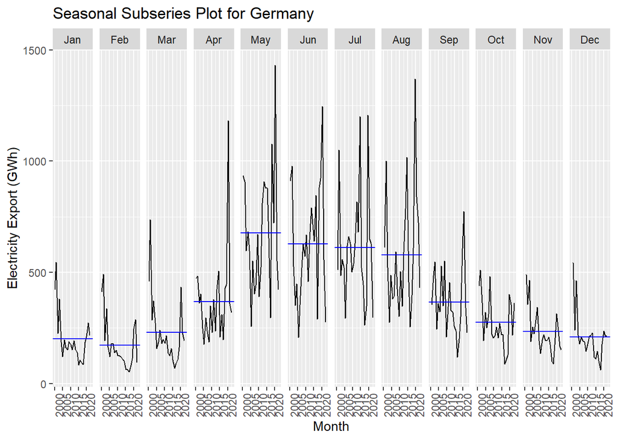

```r
# Display the plots
print(germany_plot)
```

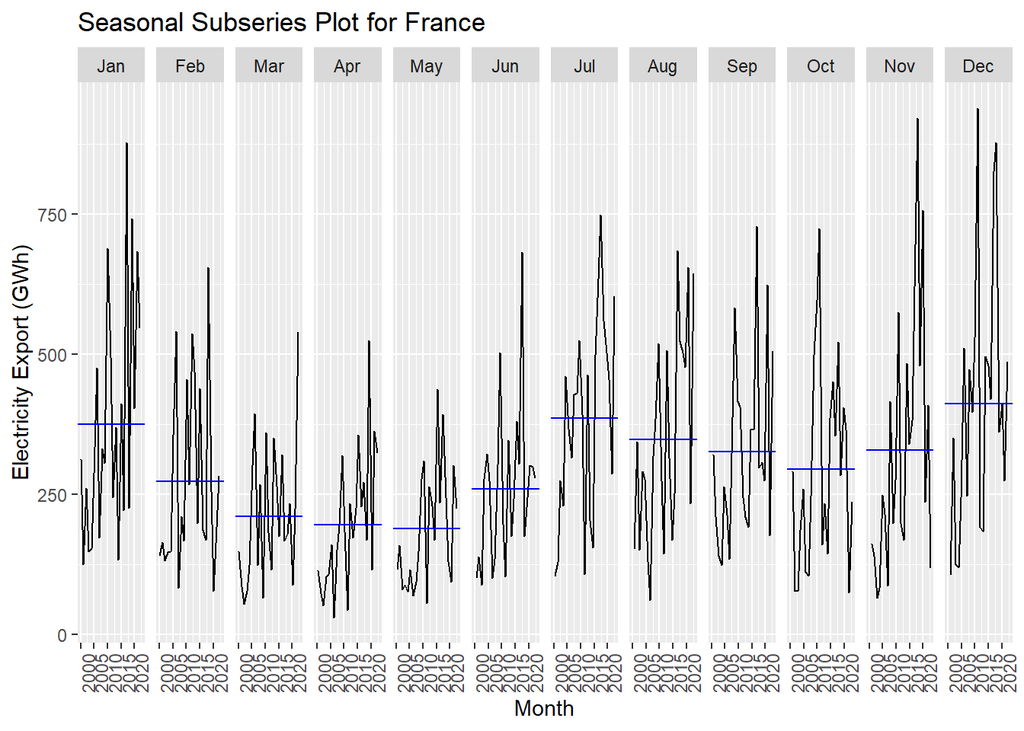

```r
print(france_plot)
```

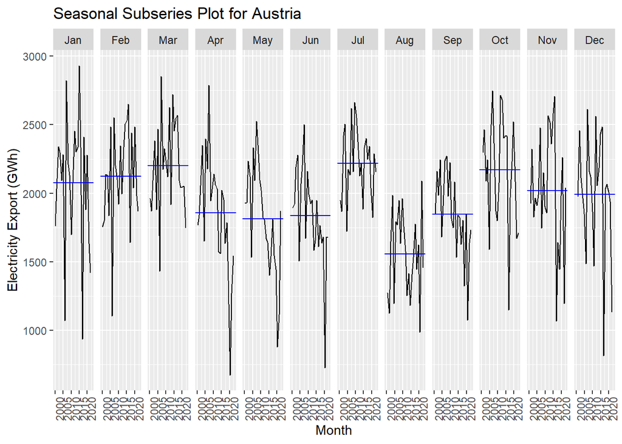

```r
print(austria_plot)
```

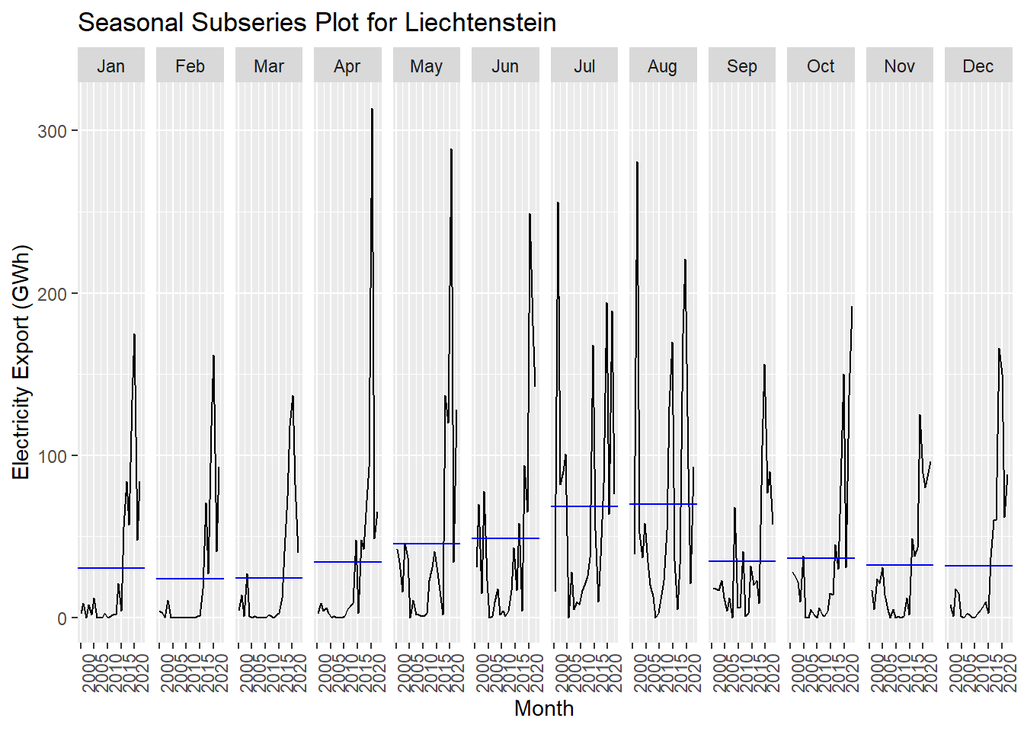

```r
print(liechtenstein_plot)
```

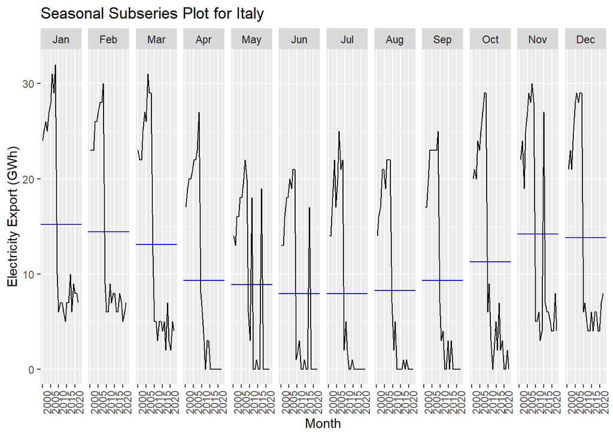

```r
print(italy_plot)
```

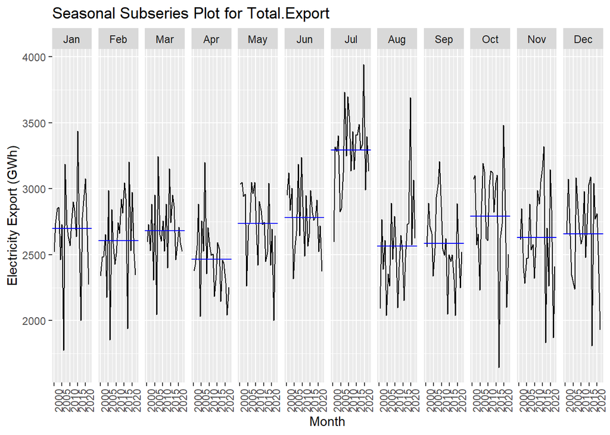

```r
print(total_export_plot)
```

# Modeling

Lets display some of the methods in order to forecast

## ETS model

```r
fit_and_forecast_ets <- function(ts_data, country) {
  # Fit the ETS model with ZZZ (chooses automatically the best)
  ets_model <- ets(ts_data, "ZZZ")

  # Print the chosen model
  cat("Chosen ETS model for", country, ":", ets_model$components, "\n")

  # Generate a forecast
  ets_forecast <- forecast(ets_model, h = 12) # Forecast 12 months ahead

  # Plot the forecast
  plot(ets_forecast, main = paste("ETS Forecast for", country))
}
```

Please look at the appendix for the graphs.

So here is what R chooses automatically for us :

## ARIMA model

```r
# Load the forecast package
library(forecast)

# Function to fit and forecast ARIMA model
fit_and_forecast_arima <- function(ts_data, country) {
  # Fit the ARIMA model
  arima_model <- auto.arima(ts_data, seasonal = FALSE)

  # Generate a forecast
  arima_forecast <- forecast(arima_model, h = 12) # Forecast 12 months ahead

  # Plot the forecast
  plot(arima_forecast, main = paste("ARIMA Forecast for", country))
}
```

Please look at the appendix for the graphs.

## SARIMA (ARIMA with seasonality)

```r
# Load the forecast package
library(forecast)

# Function to fit and forecast ARIMA model
fit_and_forecast_sarima <- function(ts_data, country) {
  # Fit the ARIMA model
  sarima_model <- auto.arima(ts_data, seasonal = TRUE, D = 1) #D=1 forces the seasonality

  # Generate a forecast
  sarima_forecast <- forecast(sarima_model, h = 12) # Forecast 12 months ahead

  # Plot the forecast
  plot(sarima_forecast, main = paste("SARIMA Forecast for", country))
}
```

Please look at the appendix for the graphs.

We forced the differentiation by passing `D=1` as an option. This way, forecasts such as the one from the Liechtenstein won’t be a straight line. See the Stackoverflow discussion: https://stats.stackexchange.com/questions/286900/arima-forecast-straight-line

## AIC VS BIC

Here we are comparing all our models based on the AIC and BIC with the same training/testing set.

```r
library(forecast)

compare_modelsAIC <- function(ts_data) {
  # Train-test split
  train_data <- window(ts_data, end = c(2019, 12))
  test_data <- window(ts_data, start = c(2020, 1))

  # ETS models
  ets_zzz <- ets(train_data, model = "ZZZ")
  ets_ana <- ets(train_data, model = "ANA")

  if (all(train_data > 0)) {
    ets_mnm <- ets(train_data, model = "MNM")
  }

  ets_aaa <- ets(train_data, model = "AAA")

  # ARIMA model
  arima_model <- auto.arima(train_data, seasonal = FALSE)

  # SARIMA model
  sarima_model <- auto.arima(train_data, seasonal=TRUE, D=1)

  # Store AIC and BIC values
  aic_values <- c(ets_zzz = ets_zzz$aic, ets_ana = ets_ana$aic, ets_aaa = ets_aaa$aic, arima = arima_model$aic, sarima = sarima_model$aic)
  bic_values <- c(ets_zzz = ets_zzz$bic, ets_ana = ets_ana$bic, ets_aaa = ets_aaa$bic, arima = arima_model$bic, sarima = sarima_model$bic)

  if (exists("ets_mnm")) {
    aic_values <- c(aic_values, ets_mnm = ets_mnm$aic)
    bic_values <- c(bic_values, ets_mnm = ets_mnm$bic)
  }

  # Find the model with the lowest AIC and BIC values
  best_aic_model <- names(which.min(aic_values))
  best_bic_model <- names(which.min(bic_values))

  cat("Best model according to AIC:", best_aic_model, "\n")
  cat("Best model according to BIC:", best_bic_model, "\n")

  return(list(AIC = aic_values, BIC = bic_values))
}
```

For Germany:

```r
compare_modelsAIC(ts_germany)
```

```
## Best model according to AIC: sarima
## Best model according to BIC: sarima
```

```
## $AIC
##  ets_zzz  ets_ana  ets_aaa    arima   sarima  ets_mnm
## 3539.677 3706.164 3710.756 3142.403 2913.547 3539.677
##
## $BIC
##  ets_zzz  ets_ana  ets_aaa    arima   sarima  ets_mnm
## 3591.887 3758.373 3769.927 3163.287 2930.694 3591.887
```

SARIMA is the best model for Germany according to AIC and BIC

For Italy :

```r
compare_modelsAIC(ts_italy)
```

```
## Best model according to AIC: sarima
## Best model according to BIC: sarima
```

```
## $AIC
##  ets_zzz  ets_ana  ets_aaa    arima   sarima
## 1935.472 1935.472 1938.654 1326.208 1247.411
##
## $BIC
##  ets_zzz  ets_ana  ets_aaa    arima   sarima
## 1987.682 1987.682 1997.824 1336.637 1267.987
```

SARIMA is the best model for Italy according to AIC and BIC

For Austria :

```r
compare_modelsAIC(ts_austria)
```

```
## Best model according to AIC: sarima
## Best model according to BIC: sarima
```

```
## $AIC
##  ets_zzz  ets_ana  ets_aaa    arima   sarima  ets_mnm
## 4050.636 4050.636 4055.213 3488.123 3226.996 4110.606
##
## $BIC
##  ets_zzz  ets_ana  ets_aaa    arima   sarima  ets_mnm
## 4102.846 4102.846 4114.384 3498.565 3237.284 4162.816
```

SARIMA is the best model for Austria according to AIC and BIC

For France :

```r
compare_modelsAIC(ts_france)
```

```
## Best model according to AIC: sarima
## Best model according to BIC: sarima
```

```
## $AIC
##  ets_zzz  ets_ana  ets_aaa    arima   sarima  ets_mnm
## 3653.198 3726.256 3730.226 3079.729 2953.574 3653.198
##
## $BIC
##  ets_zzz  ets_ana  ets_aaa    arima   sarima  ets_mnm
## 3705.408 3778.466 3789.397 3090.158 2963.862 3705.408
```

For Liechtenstein :

```r
compare_modelsAIC(ts_liechtenstein)
```

```
## Best model according to AIC: sarima
## Best model according to BIC: sarima
```

```
## $AIC
##  ets_zzz  ets_ana  ets_aaa    arima   sarima
## 2981.328 2981.328 2984.322 2339.161 2217.785
##
## $BIC
##  ets_zzz  ets_ana  ets_aaa    arima   sarima
## 3033.538 3033.538 3043.493 2356.543 2238.335
```

SARIMA is the best model for Liechtenstein according to AIC and BIC

For overall data :

```r
compare_modelsAIC(ts_data)
```

```
## Best model according to AIC: sarima
## Best model according to BIC: sarima
```

```
## $AIC
##  ets_zzz  ets_ana  ets_aaa    arima   sarima  ets_mnm
## 4037.984 4037.984 4043.432 3491.954 3227.779 4059.792
##
## $BIC
##  ets_zzz  ets_ana  ets_aaa    arima   sarima  ets_mnm
## 4090.193 4090.193 4106.084 3505.877 3244.926 4112.001
```

Here is the calculation just for Italy.

```r
# Adjust the Italy data to start from 2009
ts_italy <- window(ts_italy, start = c(2009, 1))

# Train-test split
 train_data <- window(ts_italy, end = c(2020, 12))
 test_data <- window(ts_italy, start = c(2021, 1))

# ETS models
ets_zzz <- ets(train_data, model = "ZZZ")
ets_ana <- ets(train_data, model = "ANA")

if (all(train_data > 0)) {
    ets_mnm <- ets(train_data, model = "MNM")
}

ets_aaa <- ets(train_data, model = "AAA")

# ARIMA model
arima_model <- auto.arima(train_data, seasonal = FALSE)

# SARIMA model
sarima_model <- auto.arima(train_data, seasonal=TRUE)

# Store AIC and BIC values
aic_values <- c(ets_zzz = ets_zzz$aic, ets_ana = ets_ana$aic, ets_aaa = ets_aaa$aic, arima = arima_model$aic, sarima = sarima_model$aic)
bic_values <- c(ets_zzz = ets_zzz$bic, ets_ana = ets_ana$bic, ets_aaa = ets_aaa$bic, arima = arima_model$bic, sarima = sarima_model$bic)

if (exists("ets_mnm")) {
    aic_values <- c(aic_values, ets_mnm = ets_mnm$aic)
    bic_values <- c(bic_values, ets_mnm = ets_mnm$bic)
}

# Find the model with the lowest AIC and BIC values
best_aic_model <- names(which.min(aic_values))
best_bic_model <- names(which.min(bic_values))

cat("Best model according to AIC:", best_aic_model, "\n")
```

```
## Best model according to AIC: sarima
```

```r
cat("Best model according to BIC:", best_bic_model, "\n")
```

```
## Best model according to BIC: arima
```

```r
print(list(AIC = aic_values, BIC = bic_values))
```

```
## $AIC
##   ets_zzz   ets_ana   ets_aaa     arima    sarima
## 1096.0028 1096.0028 1099.8513  794.0080  790.2782
##
## $BIC
##   ets_zzz   ets_ana   ets_aaa     arima    sarima
## 1140.5500 1140.5500 1150.3381  802.9174  805.1272
```

## Cross validation

In the next chuck we will perform our cross validation in order to compare the MAE of each models. As the cross-validation of the time series differs from the “standard” cross-validation methods because it will “spoil” the future values to the model, we expect it not to work as well as in other Machine Learning applications. We deliberately chose the value of `h=3`, which would be somewhat equivalent to a `3-fold` cross-validation. We did not show it here, but increasing the `h` value higher than that would result in a worse model overall, and would take significantly longer to run on our computers.

```r
library(forecast)

compare_models_cv <- function(ts_data) {
  # ETS models
  ets_zzz <- ets(ts_data, model = "ZZZ")
  ets_ana <- ets(ts_data, model = "ANA")

  if (all(ts_data > 0)) {
    ets_mnm <- ets(ts_data, model = "MNM")
  }

  ets_aaa <- ets(ts_data, model = "AAA")

  # ARIMA model
  arima_model <- auto.arima(ts_data, seasonal = FALSE)

  # SARIMA model
  sarima_model <- auto.arima(ts_data, seasonal = TRUE, D=1)

  # Cross-validation errors
  cv_errors_ets_zzz <- tsCV(ts_data, forecastfunction = forecast, h = 3, model = ets_zzz, use.initial.values = FALSE)
  cv_errors_ets_ana <- tsCV(ts_data, forecastfunction = forecast, h = 3, model = ets_ana, use.initial.values = FALSE)
  cv_errors_ets_aaa <- tsCV(ts_data, forecastfunction = forecast, h = 3, model = ets_aaa, use.initial.values = FALSE)
  cv_errors_arima <- tsCV(ts_data, forecastfunction = forecast, h = 3, model = arima_model, use.initial.values = FALSE)
  cv_errors_sarima <- tsCV(ts_data, forecastfunction = forecast, h = 3, model = sarima_model, use.initial.values = FALSE)

  if (exists("ets_mnm")) {
    cv_errors_ets_mnm <- tsCV(ts_data, forecastfunction = forecast, h = 3, model = ets_mnm, use.initial.values = FALSE)
  }

  # Calculate MAE
  mae_ets_zzz <- mean(abs(cv_errors_ets_zzz), na.rm = TRUE)
  mae_ets_ana <- mean(abs(cv_errors_ets_ana), na.rm = TRUE)
  mae_ets_aaa <- mean(abs(cv_errors_ets_aaa), na.rm = TRUE)
  mae_arima <- mean(abs(cv_errors_arima), na.rm = TRUE)
  mae_sarima <- mean(abs(cv_errors_sarima), na.rm = TRUE)

  if (exists("cv_errors_ets_mnm")) {
    mae_ets_mnm <- mean(abs(cv_errors_ets_mnm), na.rm = TRUE)
  }

  # Combine MAE results
  mae_results <- list(
    ETS_ZZZ = mae_ets_zzz,
    ETS_ANA = mae_ets_ana,
    ETS_AAA = mae_ets_aaa,
    ARIMA = mae_arima,
    SARIMA = mae_sarima
  )

  if (exists("mae_ets_mnm")) {
    mae_results$ETS_MNM <- mae_ets_mnm
  }

  # Print the MAE values
  cat("MAE values for each model:\n")
  print(mae_results)

  # Find the model with the lowest MAE
  best_model_name <- names(mae_results)[which.min(unlist(mae_results))]

  # Return the best model
  if (best_model_name == "ETS_ZZZ") {
    return(ets_zzz)
  } else if (best_model_name == "ETS_ANA") {
    return(ets_ana)
  } else if (best_model_name == "ETS_AAA") {
    return(ets_aaa)
  } else if (best_model_name == "ARIMA") {
    return(arima_model)
  } else if (best_model_name == "SARIMA") {
    return(sarima_model)
  } else if (exists("ets_mnm") && best_model_name == "ETS_MNM") {
    return(ets_mnm)
  } else {
    return(NULL)
  }
}
```

For Germany:

```r
best_model_germany <- compare_models_cv(ts_germany)
```

```
## MAE values for each model:
## $ETS_ZZZ
## [1] 124.8497
##
## $ETS_ANA
## [1] 134.1596
##
## $ETS_AAA
## [1] 133.6411
##
## $ARIMA
## [1] 140.8473
##
## $SARIMA
## [1] 118.0983
##
## $ETS_MNM
## [1] 123.2806
```

```r
print(best_model_germany)
```

```
## Series: ts_data
## ARIMA(1,0,0)(1,1,2)[12]
##
## Coefficients:
##          ar1     sar1     sma1     sma2
##       0.6858  -0.3289  -0.5122  -0.2163
## s.e.  0.0462   0.4501   0.4531   0.3725
##
## sigma^2 = 20983:  log likelihood = -1686.32
## AIC=3382.65   AICc=3382.88   BIC=3400.51
```

The cross-validation chooses a `SARIMA.` We can observe that the closest ETS model is an MNM, which is only 5 points higher.

For Italy :

```r
compare_models_cv(ts_italy)
```

```
## MAE values for each model:
## $ETS_ZZZ
## [1] 2.188798
##
## $ETS_ANA
## [1] 2.188798
##
## $ETS_AAA
## [1] 2.278341
##
## $ARIMA
## [1] 2.899118
##
## $SARIMA
## [1] 2.252607
```

```
## ETS(A,N,A)
##
## Call:
##  ets(y = ts_data, model = "ZZZ")
##
##   Smoothing parameters:
##     alpha = 0.1136
##     gamma = 1e-04
##
##   Initial states:
##     l = 5.7344
##     s = 1.8209 3.105 -0.7561 -2.2523 -2.4208 -2.9241
##            -1.9638 -0.3315 -2.1763 0.9766 3.3002 3.6222
##
##   sigma:  3.3258
##
##      AIC     AICc      BIC
## 1271.458 1274.637 1318.228
```

For Italy, all the MAE are pretty much the same which can indicate that the models are all good. Our code chooses the ETS model with Additive error and seasonality.

For Austria :

```r
compare_models_cv(ts_austria)
```

```
## MAE values for each model:
## $ETS_ZZZ
## [1] 303.3289
##
## $ETS_ANA
## [1] 303.3289
##
## $ETS_AAA
## [1] 311.0406
##
## $ARIMA
## [1] 309.1512
##
## $SARIMA
## [1] 262.5357
##
## $ETS_MNM
## [1] 305.4499
```

```
## Series: ts_data
## ARIMA(1,0,0)(0,1,1)[12]
##
## Coefficients:
##          ar1     sma1
##       0.6715  -0.8058
## s.e.  0.0456   0.0410
##
## sigma^2 = 82439:  log likelihood = -1867.31
## AIC=3740.63   AICc=3740.72   BIC=3751.34
```

For France :

```r
compare_models_cv(ts_france)
```

```
## MAE values for each model:
## $ETS_ZZZ
## [1] 126.0891
##
## $ETS_ANA
## [1] 129.9876
##
## $ETS_AAA
## [1] 148.6232
##
## $ARIMA
## [1] 130.3557
##
## $SARIMA
## [1] 126.6193
##
## $ETS_MNM
## [1] 126.0891
```

```
## ETS(M,N,M)
##
## Call:
##  ets(y = ts_data, model = "ZZZ")
##
##   Smoothing parameters:
##     alpha = 0.1291
##     gamma = 1e-04
##
##   Initial states:
##     l = 170.8923
##     s = 1.2725 1.0452 0.9882 1.0959 1.1569 1.2767
##            0.9466 0.6091 0.6547 0.7549 1.0015 1.1979
##
##   sigma:  0.4921
##
##      AIC     AICc      BIC
## 4244.319 4246.172 4298.570
```

For France, the ETS with multiplicative Error and Seasonality seem the best close to the SARIMA model. The difference between the two is really small though.

For Liechtenstein :

```r
compare_models_cv(ts_liechtenstein)
```

```
## MAE values for each model:
## $ETS_ZZZ
## [1] 29.7453
##
## $ETS_ANA
## [1] 29.7453
##
## $ETS_AAA
## [1] 27.98428
##
## $ARIMA
## [1] 25.94161
##
## $SARIMA
## [1] 28.08003
```

```
## Series: ts_data
## ARIMA(0,1,2)
##
## Coefficients:
##           ma1      ma2
##       -0.3937  -0.4135
## s.e.   0.0549   0.0565
##
## sigma^2 = 1417:  log likelihood = -1382.4
## AIC=2770.8   AICc=2770.89   BIC=2781.64
```

For overall data :

```r
compare_models_cv(ts_data)
```

```
## MAE values for each model:
## $ETS_ZZZ
## [1] 267.8526
##
## $ETS_ANA
## [1] 267.8526
##
## $ETS_AAA
## [1] 275.551
##
## $ARIMA
## [1] 283.8295
##
## $SARIMA
## [1] 235.2902
##
## $ETS_MNM
## [1] 264.4758
```

```
## Series: ts_data
## ARIMA(1,0,1)(1,1,1)[12]
##
## Coefficients:
##          ar1      ma1     sar1     sma1
##       0.7124  -0.1627  -0.0456  -0.7963
## s.e.  0.0717   0.1018   0.0780   0.0560
##
## sigma^2 = 73889:  log likelihood = -1852.02
## AIC=3714.05   AICc=3714.28   BIC=3731.91
```

# Conclusion

After many discussions with the professor and the assistants from the course, we decided to use the method of `AIC` to choose our models, instead of using methods comparing the errors such as the `MAE`. You will find that most models (if not all) resulted in the same way. This might be explained because of over fitting, but we cannot be certain.

## Germany

With the AIC computed before, we can conclude that the best model came the SARIMA computed from the test / training sets with an AIC of `2913`, instead of the value of `3382` from the Cross-validation. This is quite surprising, as both methods resulted in the same output, but with different AIC.

```r
# First fit the SARIMA model to the data
sarima_model_germany <- auto.arima(ts_germany, seasonal = TRUE, D=1)

# Generate a 12 month forecast
forecast_sarima <- forecast(sarima_model_germany, h = 13)

# Print the forecast
print(forecast_sarima)
```

```
##          Point Forecast       Lo 80    Hi 80      Lo 95     Hi 95
## Dec 2022       143.2646  -42.377025 328.9062 -140.64975  427.1789
## Jan 2023       159.3608  -65.741236 384.4628 -184.90304  503.6246
## Feb 2023       135.3621 -106.078941 376.8031 -233.89010  504.6143
## Mar 2023       190.7662  -57.988464 439.5208 -189.67122  571.2036
## Apr 2023       449.9413  197.820365 702.0623   64.35558  835.5271
## May 2023       731.5511  477.862321 985.2398  343.56761 1119.5345
## Jun 2023       680.7654  426.342656 935.1882  291.65939 1069.8714
## Jul 2023       596.8109  342.043647 851.5781  207.17802  986.4437
## Aug 2023       680.9398  426.010723 935.8689  291.05942 1070.8202
## Sep 2023       379.6509  124.645754 634.6561  -10.34582  769.6476
## Oct 2023       262.2746    7.233669 517.3155 -127.77683  652.3260
## Nov 2023       195.0101  -60.047594 450.0678 -195.06698  585.0872
## Dec 2023       177.4056  -79.590547 434.4018 -215.63610  570.4473
```

## Italy

Same as in Germany, we will choose the model computed by the test / training sets instead of cross validation. Indeed, we got a `SARIMA` with an AIC of `734` instead of the `1271` from the `ETS(A,N,A)` we got in the cross-validation. Here the difference is quite significant and may be explained because we only used the data after 2015, which imitates greatly the behavior we have today.

```r
# First fit the SARIMA model to the data
sarima_model_italy <- auto.arima(ts_italy, seasonal = TRUE)

# Generate a 12 month forecast
forecast_sarima <- forecast(sarima_model_italy, h = 13)

# Print the forecast
print(forecast_sarima)
```

```
##          Point Forecast      Lo 80    Hi 80     Lo 95    Hi 95
## Dec 2022       4.253512 -0.2677007 8.774724 -2.661086 11.16811
## Jan 2023       3.972727 -0.9755297 8.920984 -3.594979 11.54043
## Feb 2023       3.913141 -1.1237009 8.949984 -3.790044 11.61633
## Mar 2023       3.426577 -1.6334655 8.486620 -4.312090 11.16525
## Apr 2023       2.303021 -2.7652839 7.371326 -5.448283 10.05432
## May 2023       2.296451 -2.7760464 7.368949 -5.461265 10.05417
## Jun 2023       2.296774 -2.7785966 7.372144 -5.465336 10.05888
## Jul 2023       2.302051 -2.7757042 7.379807 -5.463706 10.06781
## Aug 2023       2.307166 -2.7727805 7.387112 -5.461941 10.07627
## Sep 2023       2.300030 -2.7820250 7.382086 -5.472303 10.07236
## Oct 2023       2.508521 -2.5756098 7.592651 -5.266986 10.28403
## Nov 2023       3.619725 -1.4664650 8.705915 -4.158931 11.39838
## Dec 2023       3.539473 -1.6309421 8.709888 -4.367994 11.44694
```

We wanted to force seasonality but as the point forecasts came in the negative, we could not let it as-is. Also, the ETS(A,N,A) was supposed to be the best in the Cross-validation, but same conclusion because some of its point values were negative.

## Austria

```r
# First fit the SARIMA model to the data
sarima_model_austria <- auto.arima(ts_austria, seasonal = TRUE, D=1)

# Generate a 12 month forecast
forecast_sarima <- forecast(sarima_model_austria, h = 13)

# Print the forecast
print(forecast_sarima)
```

```
##          Point Forecast    Lo 80    Hi 80     Lo 95    Hi 95
## Dec 2022       1950.739 1582.772 2318.706 1387.9826 2513.496
## Jan 2023       2001.880 1558.645 2445.114 1324.0108 2679.749
## Feb 2023       2203.221 1729.945 2676.498 1479.4072 2927.036
## Mar 2023       2158.997 1672.779 2645.214 1415.3916 2902.602
## Apr 2023       1535.748 1043.806 2027.689  783.3883 2288.107
## May 2023       1539.274 1044.773 2033.775  783.0000 2295.548
## Jun 2023       1616.472 1120.821 2112.123  858.4392 2374.505
## Jul 2023       2183.338 1687.170 2679.507 1424.5139 2942.163
## Aug 2023       1548.463 1052.061 2044.865  789.2816 2307.644
## Sep 2023       1649.071 1152.564 2145.578  889.7291 2408.413
## Oct 2023       2011.699 1515.144 2508.253 1252.2842 2771.113
## Nov 2023       1877.616 1381.040 2374.192 1118.1691 2637.063
## Dec 2023       1841.022 1338.880 2343.165 1073.0624 2608.983
```

## France

Here the AIC of the `SARIMA` model was `3006`, and the one we got from the cross-validation resulted in a `ETS(M,N,M)` model with an AIC of `4244`.

```r
# First fit the SARIMA model to the data
sarima_model_france <- auto.arima(ts_france, seasonal = TRUE, D=1)

# Generate a 12 month forecast
forecast_sarima <- forecast(sarima_model_france, h = 13)

# Print the forecast
print(forecast_sarima)
```

```
##          Point Forecast      Lo 80    Hi 80       Lo 95    Hi 95
## Dec 2022       304.9784 110.106556 499.8503    6.947623 603.0092
## Jan 2023       414.2523 198.709645 629.7950   84.608251 743.8964
## Feb 2023       237.1630  17.267176 457.0587  -99.138621 573.4645
## Mar 2023       242.3951  21.538420 463.2517  -95.376021 580.1661
## Apr 2023       263.1673  42.096517 484.2380  -74.931263 601.2658
## May 2023       222.9168   1.798212 444.0353 -115.254875 561.0884
## Jun 2023       293.7559  72.626638 514.8851  -44.432103 631.9438
## Jul 2023       465.9349 244.803322 687.0665  127.743318 804.1265
## Aug 2023       456.4277 235.295573 677.5599  118.235288 794.6201
## Sep 2023       379.7048 158.572548 600.8371   41.512202 717.8974
## Oct 2023       299.0912  77.958884 520.2234  -39.101469 637.2838
## Nov 2023       398.2329 177.100715 619.3651   60.040394 736.4255
## Dec 2023       437.4372 213.715807 661.1586   95.284850 779.5896
```

## Liechtenstein

For Liechtenstein, we got the same output here and we chose the `SARIMA` model from the test/train split with an AIC of `2339`. The model we got from the 3-fold cross-validation was `ARIMA(0,1,2)` with an AIC of `2770`.

```r
# First fit the SARIMA model to the data
sarima_model_liechenstein <- auto.arima(ts_liechtenstein, seasonal = TRUE, D=1)

# Generate a 12 month forecast
forecast_sarima <- forecast(sarima_model_liechenstein, h = 13)

# Print the forecast
print(forecast_sarima)
```

```
##          Point Forecast     Lo 80    Hi 80      Lo 95    Hi 95
## Dec 2022      109.20125 58.690523 159.7120  31.951759 186.4507
## Jan 2023      100.58213 43.136807 158.0275  12.727087 188.4372
## Feb 2023       85.15132 23.638804 146.6638  -8.923957 179.2266
## Mar 2023       79.15796 15.154277 143.1616 -18.727227 177.0432
## Apr 2023       93.70577 28.142447 159.2691  -6.564678 193.9762
## May 2023      100.73463 34.182807 167.2865  -1.047600 202.5169
## Jun 2023      115.10858 47.925657 182.2915  12.361164 217.8560
## Jul 2023      107.29777 39.710116 174.8854   3.931373 210.6642
## Aug 2023       91.75656 23.908632 159.6045 -12.007892 195.5210
## Sep 2023       71.46926  3.453661 139.4849 -32.551623 175.4901
## Oct 2023       91.98469 23.860960 160.1084 -12.201564 196.1709
## Nov 2023       71.68191  3.488410 139.8754 -32.611051 175.9749
## Dec 2023       82.66915 13.747392 151.5909 -22.737581 188.0759
```

## Overall data

Finally, as you might have guessed, we found that the best model here was SARIMA.

```r
# First fit the SARIMA model to the data
sarima_model_data <- auto.arima(ts_data, seasonal = TRUE, D=1)

# Generate a 12 month forecast
forecast_sarima <- forecast(sarima_model_data, h = 13)

# Print the forecast
print(forecast_sarima)
```

```
##          Point Forecast    Lo 80    Hi 80    Lo 95    Hi 95
## Dec 2022       2440.316 2091.956 2788.676 1907.545 2973.087
## Jan 2023       2603.818 2206.301 3001.334 1995.868 3211.767
## Feb 2023       2578.292 2158.021 2998.563 1935.544 3221.041
## Mar 2023       2606.330 2174.971 3037.690 1946.622 3266.038
## Apr 2023       2282.840 1845.960 2719.720 1614.690 2950.991
## May 2023       2537.571 2097.916 2977.226 1865.177 3209.966
## Jun 2023       2672.837 2231.780 3113.894 1998.299 3347.375
## Jul 2023       3325.637 2883.870 3767.404 2650.013 4001.261
## Aug 2023       2766.203 2324.077 3208.330 2090.030 3442.377
## Sep 2023       2456.464 2014.155 2898.772 1780.011 3132.916
## Oct 2023       2664.023 2221.621 3106.424 1987.428 3340.617
## Nov 2023       2542.148 2099.700 2984.596 1865.482 3218.814
## Dec 2023       2518.893 2072.441 2965.346 1836.103 3201.683
```

# Appendix

## ETS PLOTS

```r
fit_and_forecast_ets(ts_germany, "Germany")
```

```
## Chosen ETS model for Germany : M A M TRUE
```

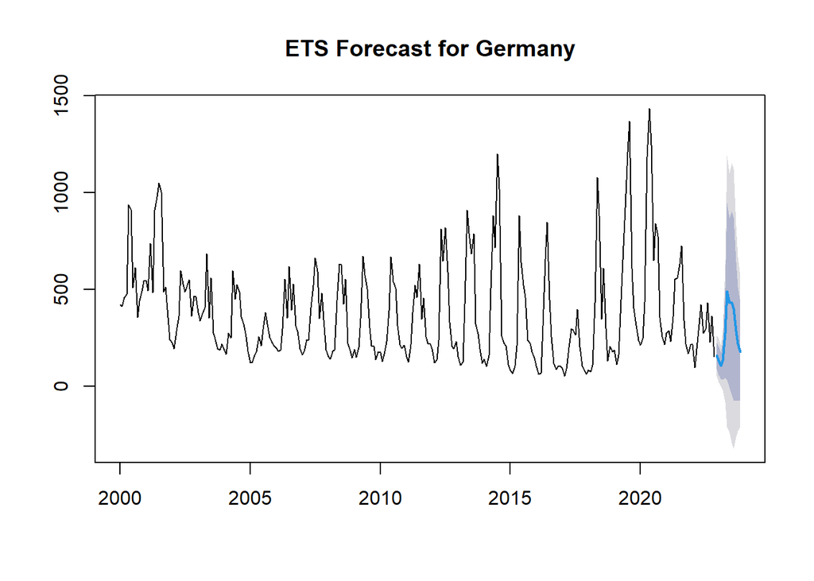

```r
fit_and_forecast_ets(ts_france, "France")
```

```
## Chosen ETS model for France : M N M FALSE
```

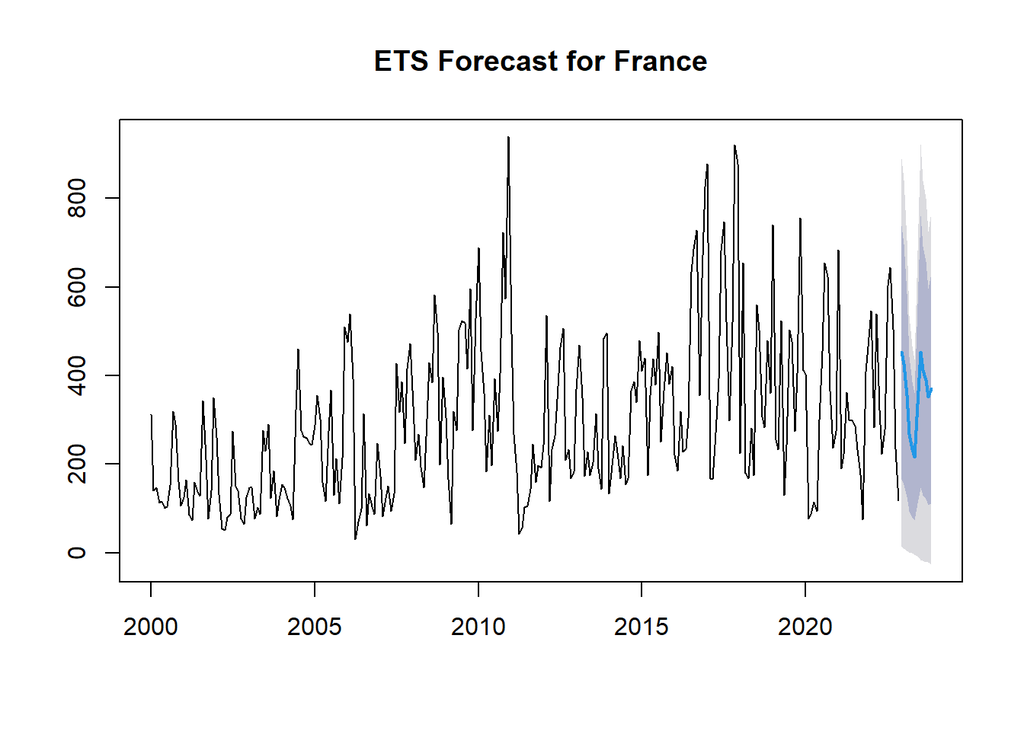

```r
fit_and_forecast_ets(ts_italy, "Italy")
```

```
## Chosen ETS model for Italy : A N A FALSE
```

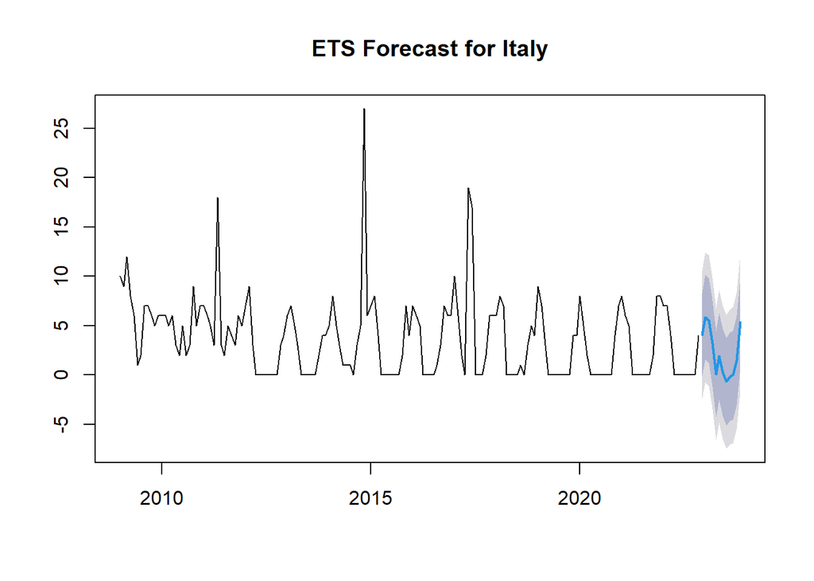

```r
fit_and_forecast_ets(ts_austria, "Austria")
```

```
## Chosen ETS model for Austria : A N A FALSE
```

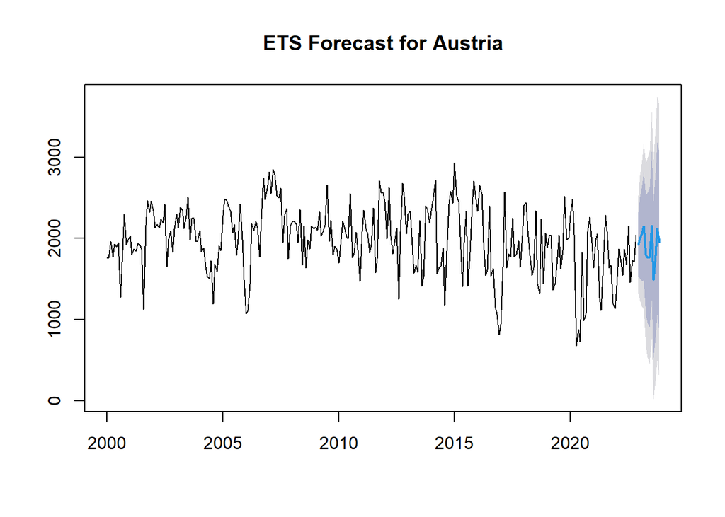

```r
fit_and_forecast_ets(ts_liechtenstein, "Liechtenstein")
```

```
## Chosen ETS model for Liechtenstein : A N A FALSE
```

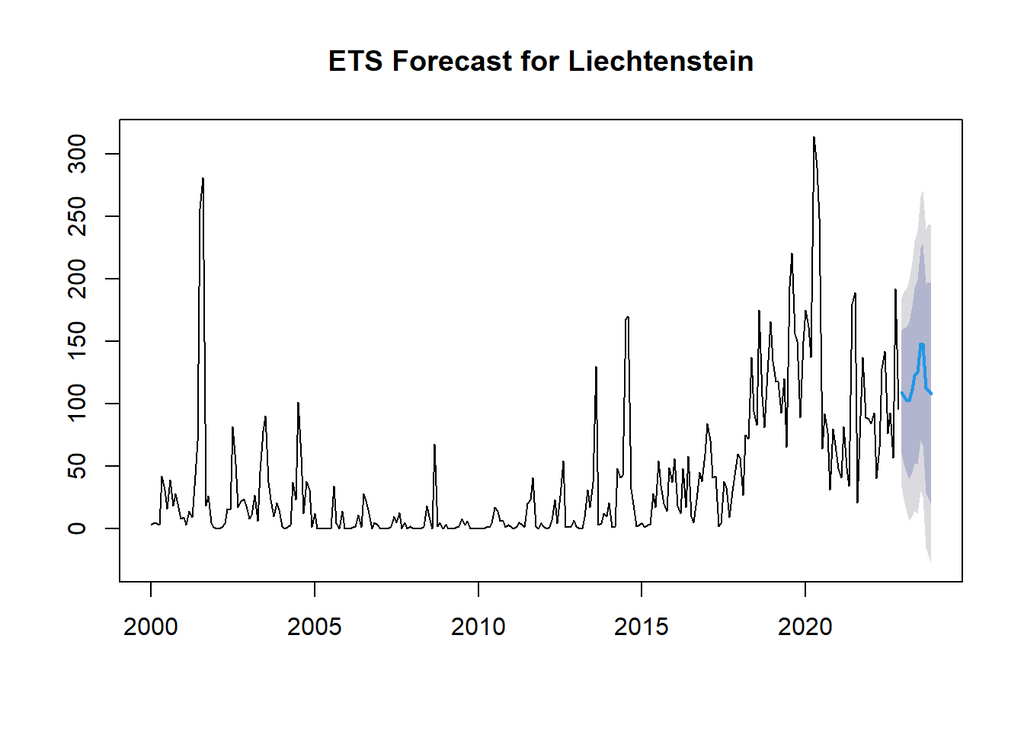

```r
fit_and_forecast_ets(ts_data, "Total.Export")
```

```
## Chosen ETS model for Total.Export : A N A FALSE
```

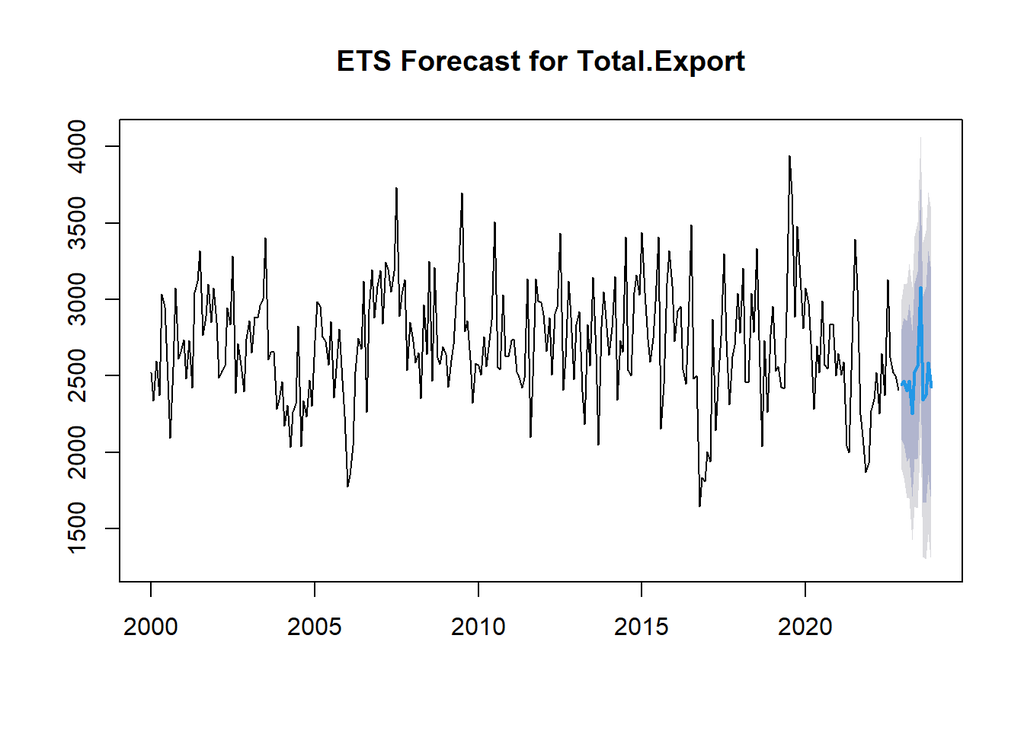

## ARIMA PLOTS

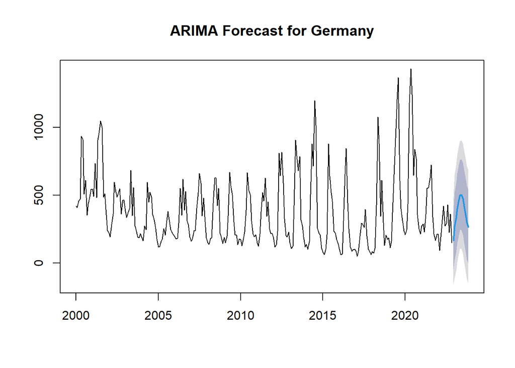

```r
fit_and_forecast_arima(ts_germany, "Germany")
```

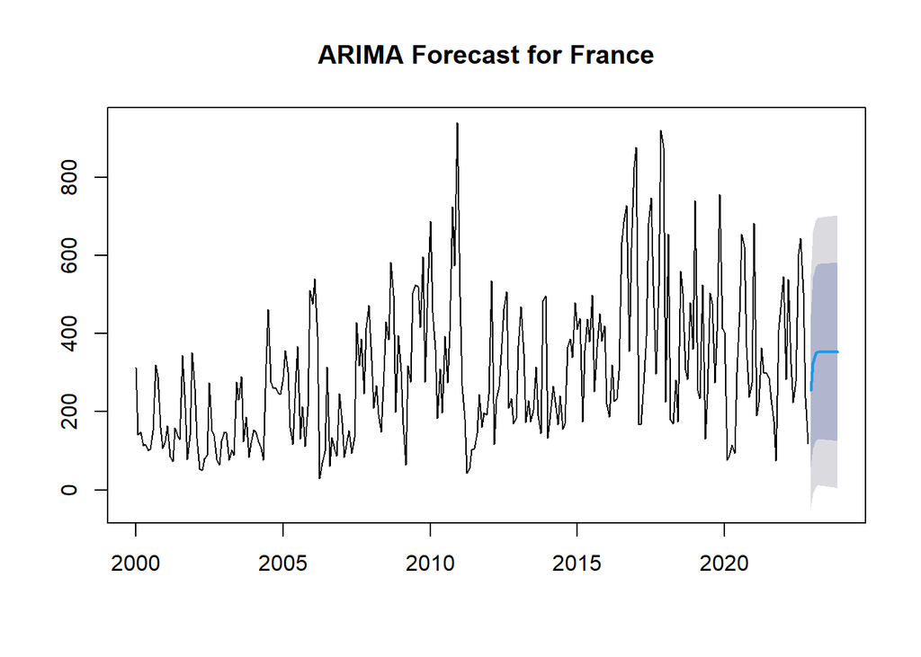

```r
fit_and_forecast_arima(ts_france, "France")
```

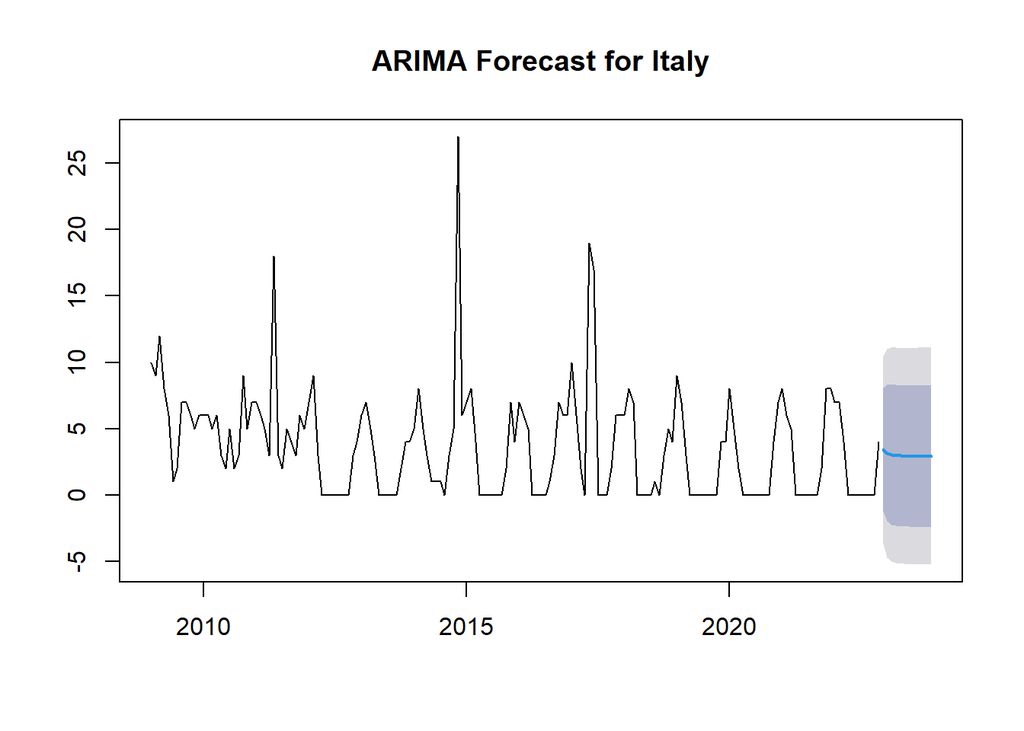

```r
fit_and_forecast_arima(ts_italy, "Italy")
```

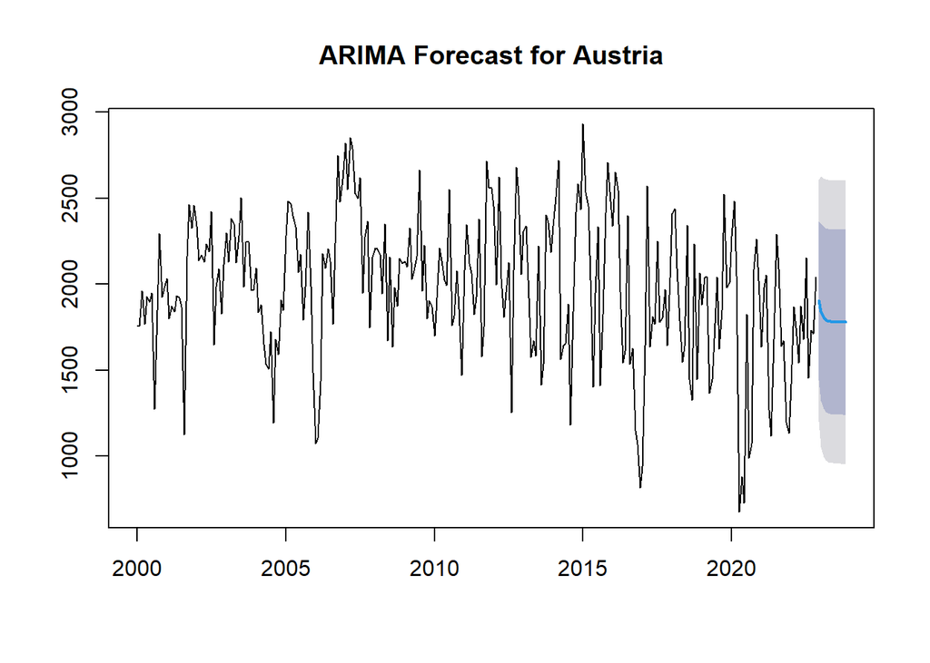

```r
fit_and_forecast_arima(ts_austria, "Austria")
```

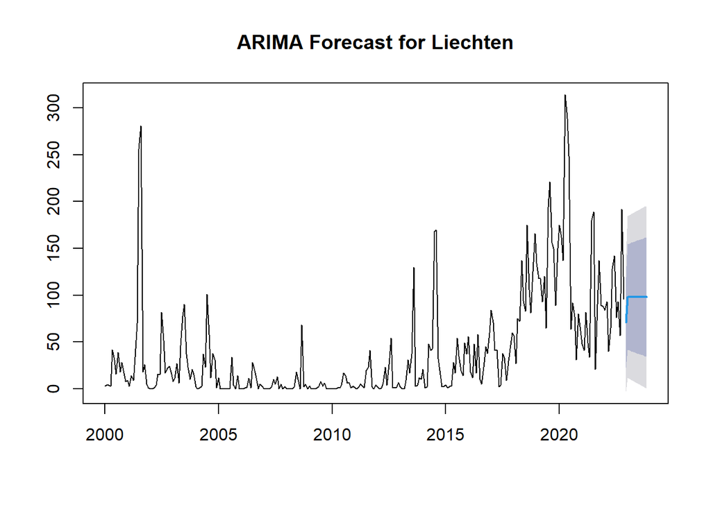

```r
fit_and_forecast_arima(ts_liechtenstein, "Liechten")
```

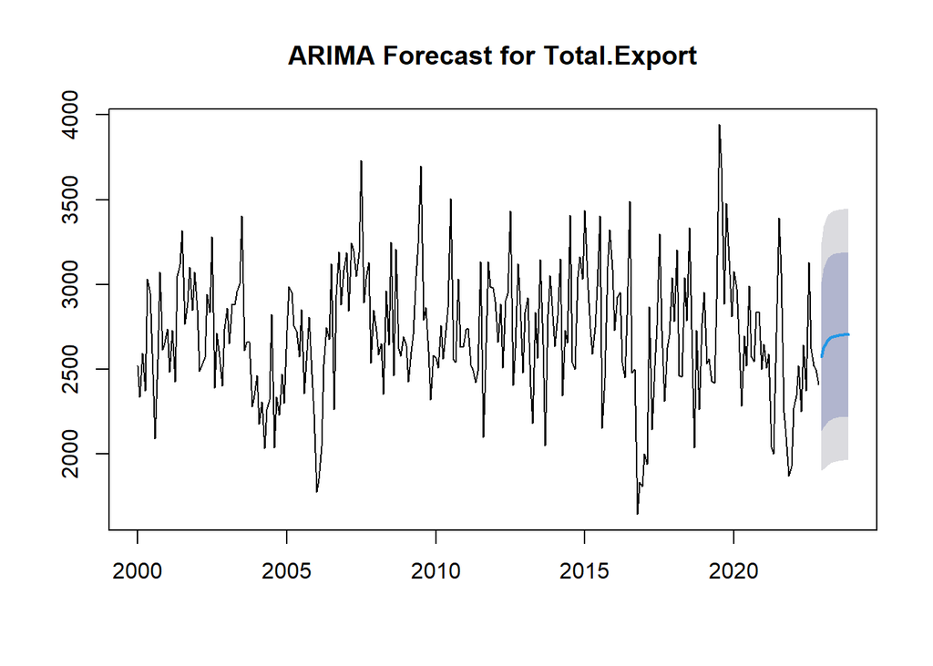

```r
fit_and_forecast_arima(ts_data, "Total.Export")
```